# Heart Attact

Author

Tymoteusz Romanowicz, Patryk Tokarski

## Źródło danych

### Zawartość zbioru:

Dane do zbioru były zbierane podczas transportu karetką do szpitala pacjentów, którzy podejrzewali u siebie obecność zawału serca. Zawał mięśnia sercowego, potocznie zwany atakiem serca to martwica mięśnia sercowego spowodowana jego niedokrwieniem wskutek zamknięcia tętnicy wieńcowej doprowadzającej krew do serca. W Europie choroby układu krążenia są najczęstszą przyczyną zgonów. Z powodu schorzeń sercowo-naczyniowych w tym zawału mięśnia sercowego, umiera dwa razy więcej osób niż z powodu chorób nowotworowych. Zbiór danych zawiera 1319 obserwacji i 9 cech, z czego jedna odnosi się do obecności ataku serca.

Wiek, płeć, tętno, skurczowe ciśnienie tętnicze, rozkurczowe ciśnienie tętnicze, poziom cukru we krwi, CK-MB (kineaza kreatynowa) i troponina reprezentują pola wejściowe, podczas gdy pole wyjściowe odnosi się do obecności zawału serca, który jest podzielone na dwie kategorie (0 i 1); “0” odnosi się do braku zawału serca, podczas gdy “1” odnosi się do obecności zawału serca.

### Przedstawienie zmiennych: opis jakie są i co znaczą

Cechy i ich opisy

| Cecha | Opis |
| --- | --- |
| Age | Wiek pacjenta w latach |
| Gender | Płeć pacjenta (0 - kobieta, 1 - mężczyzna) |
| Heart Rate | Maksymalne osiągnięte tętno (za prawidłowe tętno uznaje się przedział od 60 do 100 uderzeń serca na minutę) |
| Systolic blood pressure | Spoczynkowe skurczowe ciśnienie krwi (w mmHg, podczas dojazdu do szpitala) (normalne wartości 90-120 mmHg) |
| Diastolic blood pressure | Spoczynkowe rozkurczowe ciśnienie krwi (w mmHg, podczas dojazdu do szpitala) (normalne wartości od 60-80 mmHg) |
| Blood sugar | Poziom cukru we krwi (normalne wartości do 140mg/dl) |
| CK-MB | Enzym CK-MB (mężczyźni do 7,8 ng/mL, kobiety do 4,4 ng/mL). Jest to enzym kinazy kreatynowej. |
| Troponin | Enzym troponiny (wartości normalne do 0,03 mikrogramów) |
| Result | Obecność zawału (0 - brak zawału, 1 - zawał) |

## Cele badawcze

- Opracowanie modelu predykcyjnego, który na podstawie danych o pacjencie (wiek, płeć, tętno, ciśnienie krwi, poziom cukru we krwi, CK-MB, troponina), przewiduje czy miał on zawał serca.
- Dokonanie segmentacji pacjentów, aby zidentyfikować grupy pacjentów o podobnym ryzyku wystąpienia zawału serca.
- Używając technik wizualizacji danych wykryć wzorce i nietypowe zachowania w zbiorze danych, a także lepiej zrozumieć rozkłady poszczególnych zmiennych.

## Przygotowanie zbioru / weryfikacja poprawnosci danych / brakujace wartosci

```r
library(tidyverse)
library(foreign)

# wczytanie zbioru
df <- read.arff("data/Medicaldataset.arff")
df <- df %>% rename(
  "Age" = age,
  "Gender" = gender,
  "Heart Rate" = impluse,
  "Systolic.blood.pressure" = pressurehight,
  "Diastolic.blood.pressure" = pressurelow,
  "Blood.sugar" = glucose,
  "CK.MB" = kcm,
  "Troponin" = troponin,
  "Result" = class
)
```

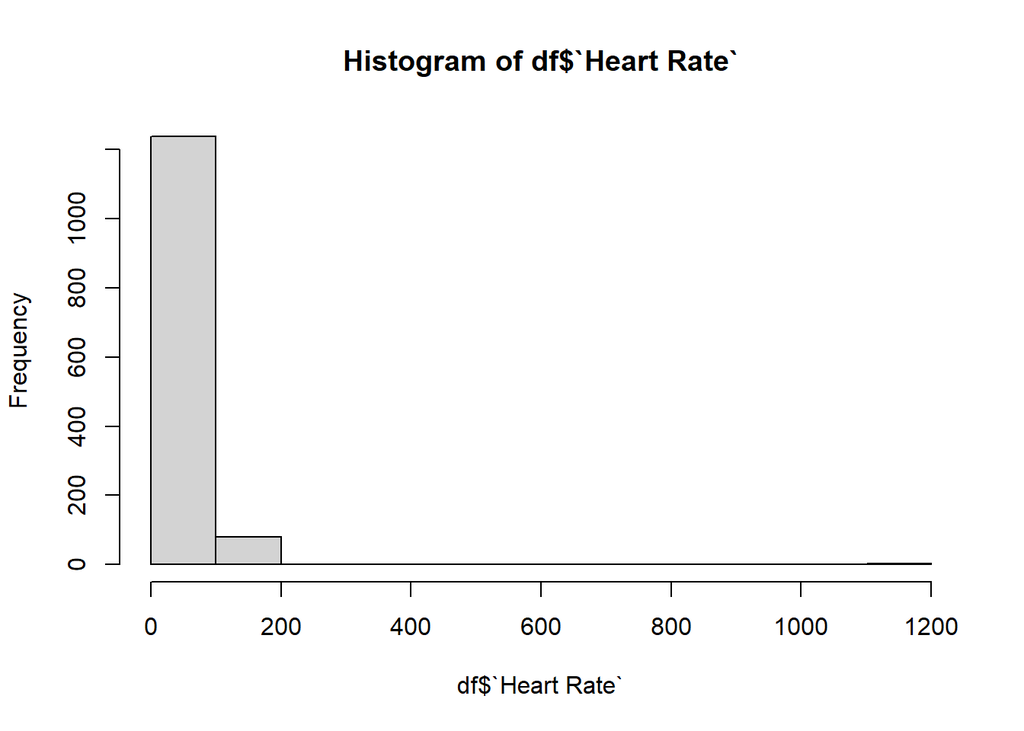

```r
hist(df$`Heart Rate`)
```

```r
df[df$`Heart Rate`>400, ]
```

```
     Age Gender Heart Rate Systolic.blood.pressure Diastolic.blood.pressure
64    45      1       1111                     141                       95
718   70      0       1111                     141                       95
1070  32      0       1111                     141                       95
     Blood.sugar CK.MB Troponin   Result
64           109  1.33    1.010 positive
718          138  3.87    0.028 positive
1070          82  2.66    0.008 negative
```

Występują trzy obserwacje, w których tętno wynosi 1111. Normalne tętno wynosi maksymalnie 100 uderzeń serca na minutę więc są to nieprawidłowe dane, najprawdopodobniej spowodowane błędem przy wpisywaniu danych, które należy usunąć.

```r
#czyszczenie zbioru, zamiana wartosci na factor
df <- df[df$`Heart Rate` != 1111, ]

str(df)
```

```
'data.frame':   1316 obs. of  9 variables:
 $ Age                     : num  64 21 55 64 55 58 32 63 44 67 ...
 $ Gender                  : num  1 1 1 1 1 0 0 1 0 1 ...
 $ Heart Rate              : num  66 94 64 70 64 61 40 60 60 61 ...
 $ Systolic.blood.pressure : num  160 98 160 120 112 112 179 214 154 160 ...
 $ Diastolic.blood.pressure: num  83 46 77 55 65 58 68 82 81 95 ...
 $ Blood.sugar             : num  160 296 270 270 300 87 102 87 135 100 ...
 $ CK.MB                   : num  1.8 6.75 1.99 13.87 1.08 ...
 $ Troponin                : num  0.012 1.06 0.003 0.122 0.003 0.004 0.003 2.37 0.004 0.011 ...
 $ Result                  : Factor w/ 3 levels "negative","positive",..: 1 2 1 2 1 1 1 2 1 1 ...
```

```r
df$Result <- ifelse(df$Result == "positive", 1, 0)

df$Gender <- as.factor(df$Gender)
df$Result <- as.factor(df$Result)
```

## Opis zbioru

Cechy jakościowe:

```r
library(pander)
pander(summary(df[c("Gender", "Result")]))
```

| Gender | Result |
| --- | --- |
| 0:447 | 0:509 |
| 1:869 | 1:807 |

Cechy ilościowe:

```r
library(rstatix)
df %>% get_summary_stats(show = c("min", "median","mean", "sd", "max")) %>% select(-n) %>%  pander()
```

| variable | min | median | mean | sd | max |
| --- | --- | --- | --- | --- | --- |
| Age | 14 | 58 | 56.21 | 13.64 | 103 |
| Heart Rate | 20 | 74 | 75.98 | 15.28 | 135 |
| Systolic.blood.pressure | 42 | 124 | 127.1 | 26.14 | 223 |
| Diastolic.blood.pressure | 38 | 72 | 72.22 | 14.01 | 154 |
| Blood.sugar | 35 | 116 | 146.7 | 74.98 | 541 |
| CK.MB | 0.321 | 2.85 | 15.3 | 46.38 | 300 |
| Troponin | 0.001 | 0.014 | 0.361 | 1.156 | 10.3 |

## Wizualizacja

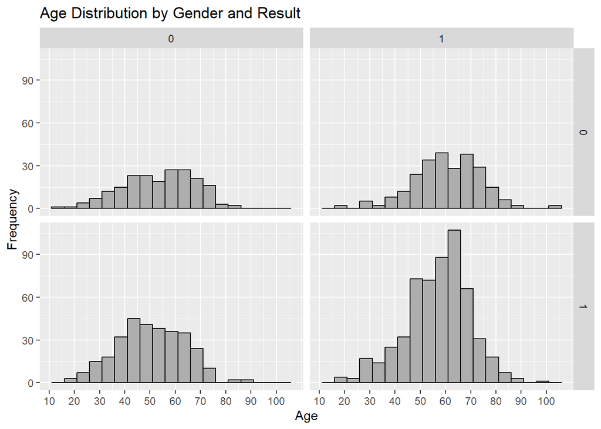

```r
ggplot(df, aes(x = Age)) +
  geom_histogram(binwidth = 5, color = "black", fill = "#aeaeae", boundary=1) +
    scale_x_continuous(breaks = seq(0, 100, by = 10)) +
  facet_grid(Gender ~ Result) +
  labs(title = "Age Distribution by Gender and Result", x = "Age", y = "Frequency")
```

[figure not shown]

```r
df %>% filter(Result=="Positive")%>%  ggplot(aes(y=Age,fill=Gender))+
  geom_boxplot()
```

```r
wiek_mezczyzn <- df %>% filter(Gender==1, Result==1) %>% select(Age)
wiek_kobiet <- df %>% filter(Gender==0,Result==1) %>% select(Age)
t.test(wiek_mezczyzn, wiek_kobiet)
```

```
    Welch Two Sample t-test

data:  wiek_mezczyzn and wiek_kobiet
t = -3.6223, df = 446.23, p-value = 0.0003256
alternative hypothesis: true difference in means is not equal to 0
95 percent confidence interval:
 -5.609412 -1.663446
sample estimates:
mean of x mean of y
 57.66845  61.30488
```

```r
df %>% group_by(Gender) %>%
  summarise(n=n(), "Percent of Positive"=round(sum(Result==1)/n(),2))
```

```
# A tibble: 2 × 3
  Gender     n `Percent of Positive`
  <fct>  <int>                 <dbl>
1 0        447                  0.55
2 1        869                  0.65
```

Na podstawie testu chi-kwadrat jak i test proporcjonalności odrzucamy hipotezę o rowności procenta pozytywnych przypadków ataku serca ze względu na płeć. Wynika z tego, że większą szansę na atak serca mają mężczyźni.

```r
# Tworzenie tablicy przestawnej
table <- table(df$Gender, df$Result)

# Przeprowadzenie testu proporcji (z testem chi-kwadrat)
result_prop_test <- prop.test(table)
chi_square_test <- chisq.test(table)

data.frame("Proportion test"=round(result_prop_test$p.value,3),
           "Chi-Square test"=round(chi_square_test$p.value,3)) %>% pander()
```

| Proportion.test | Chi.Square.test |
| --- | --- |
| 0.001 | 0.001 |

### Wykres zależności CK.MB od Troponiny z podziałem na pacjentów z zawałem i bez

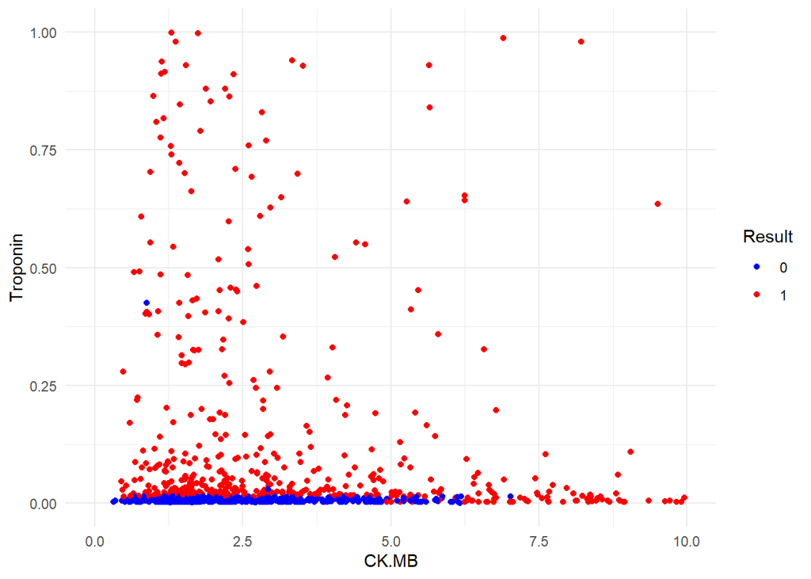

```r
ggplot(df, aes(x = CK.MB, y = Troponin, col = factor(Result))) + geom_point() +
  scale_color_manual(values = c("0" = "blue", "1" = "red")) +
  labs(x = "CK.MB", y = "Troponin", col = "Result") + scale_x_continuous(limits = c(0, 10)) + scale_y_continuous(limits = c(0, 1)) + theme_minimal()
```

Wykrycie obserwacji odstających:

```r
library(rstatix)
names(df)
```

```
[1] "Age"                      "Gender"
[3] "Heart Rate"               "Systolic.blood.pressure"
[5] "Diastolic.blood.pressure" "Blood.sugar"
[7] "CK.MB"                    "Troponin"
[9] "Result"
```

```r
zmienne <- c("Age", "Diastolic.blood.pressure")
identify_outliers(df["Troponin"])
```

```
    Troponin is.outlier is.extreme
1      1.060       TRUE       TRUE
2      2.370       TRUE       TRUE
3      5.370       TRUE       TRUE
4      0.776       TRUE       TRUE
5      0.491       TRUE       TRUE
6      0.612       TRUE       TRUE
7      1.390       TRUE       TRUE
8     10.000       TRUE       TRUE
9      8.300       TRUE       TRUE
10     1.150       TRUE       TRUE
11     0.703       TRUE       TRUE
12     0.219       TRUE      FALSE
13     0.864       TRUE       TRUE
14     0.888       TRUE       TRUE
```

[output cut: 242 more lines]

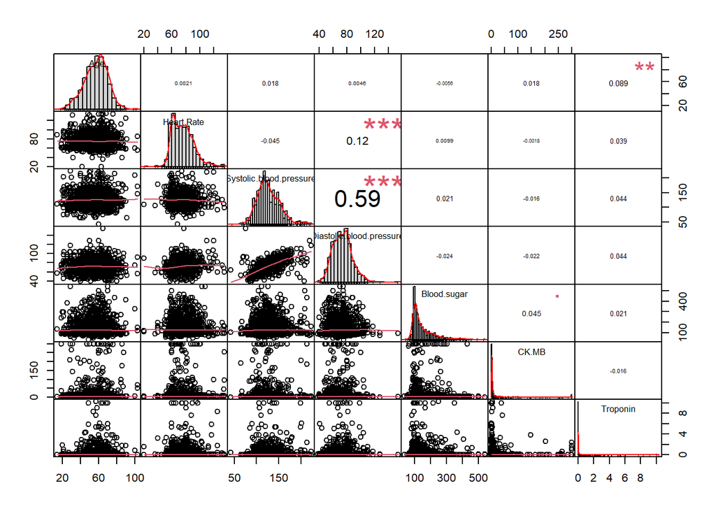

```r
library(corrplot)
library(knitr)
library(PerformanceAnalytics)

chart.Correlation(df[,c(1,3:8)])
```

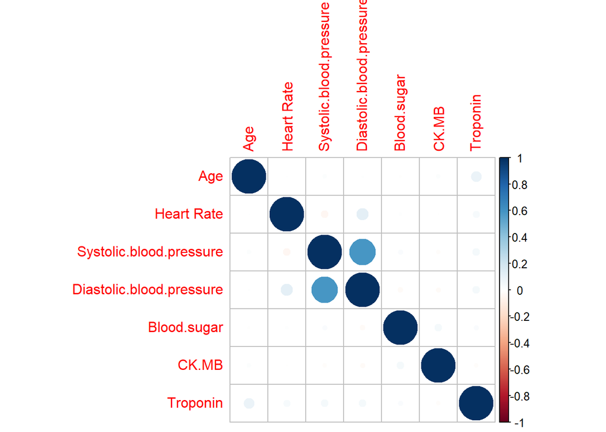

```r
corrplot(cor(df[,c(1,3:8)]))
```

GLM założenia: - Homogeneity of variance - levene test - Normality of residuals - shapiro-wilk

```r
tail(df[df$CK.MB>=300, ])
```

```
     Age Gender Heart Rate Systolic.blood.pressure Diastolic.blood.pressure
998   86      1         60                     154                       81
1048  55      0         96                     105                       70
1210  59      1         87                     148                       89
1216  63      1        101                     102                       63
1260  68      0         59                     107                       64
1281  31      1         72                     117                       49
     Blood.sugar CK.MB Troponin Result
998          112   300    1.790      1
1048          66   300    0.003      1
1210         431   300    1.230      1
1216         166   300    0.022      1
1260         225   300    0.016      1
1281         184   300    0.005      1
```

```r
sample <- sample(c(TRUE, FALSE), nrow(df), replace=TRUE, prob=c(0.7,0.3))
test   <- df[!sample, ]
df  <- df[sample, ]


model <- glm(Result~log(CK.MB)+log(Troponin), family = 'binomial', data = df)

summary(model)
```

```
Call:
glm(formula = Result ~ log(CK.MB) + log(Troponin), family = "binomial",
    data = df)

Coefficients:
              Estimate Std. Error z value Pr(>|z|)
(Intercept)    10.5345     0.9449   11.15   <2e-16 ***
log(CK.MB)      2.0814     0.2001   10.40   <2e-16 ***
log(Troponin)   2.8226     0.2265   12.46   <2e-16 ***
---
Signif. codes:  0 '***' 0.001 '**' 0.01 '*' 0.05 '.' 0.1 ' ' 1

(Dispersion parameter for binomial family taken to be 1)

    Null deviance: 1185.70  on 890  degrees of freedom
Residual deviance:  383.03  on 888  degrees of freedom
AIC: 389.03

Number of Fisher Scoring iterations: 8
```

```r
probs <- predict(model, newdata = test, type = "response")
pred <- rep(0, length(probs))
pred[probs > .5] <- 1
table(pred, test$Result)
```

```
pred   0   1
   0 145  20
   1  23 237
```

Dalex - paczka do wyjasniania modelu

```r
library(DALEX)
#explainer <- explain(model, data = test[-9], y = test[9])
#explainer %>% model_performance()

#explainer %>% feature_importance() %>% plot()
#explainer %>% model_performance()  %>% plot()
```

install.packages(“devtools”)

devtools::install_github(“ModelOriented/ArenaR”)

install.packages(“arenar”)

## Model drzewa decyzyjnego

### Biblioteki

```r
library(foreign)
library(dplyr)
library(caret)
library(rpart)
library(rattle)
```

### Przygotowanie danych

```r
df <- read.arff("Data/Medicaldataset.arff")

df <- df %>% rename(
  "Age" = age,
  "Gender" = gender,
  "Heart Rate" = impluse,
  "Systolic.blood.pressure" = pressurehight,
  "Diastolic.blood.pressure" = pressurelow,
  "Blood.sugar" = glucose,
  "CK.MB" = kcm,
  "Troponin" = troponin,
  "Result" = class
)


df <- df[df$`Heart Rate` != 1111, ]

df$Result <- ifelse(df$Result == "positive", 1, 0)
str(df)
```

```
'data.frame':   1316 obs. of  9 variables:
 $ Age                     : num  64 21 55 64 55 58 32 63 44 67 ...
 $ Gender                  : num  1 1 1 1 1 0 0 1 0 1 ...
 $ Heart Rate              : num  66 94 64 70 64 61 40 60 60 61 ...
 $ Systolic.blood.pressure : num  160 98 160 120 112 112 179 214 154 160 ...
 $ Diastolic.blood.pressure: num  83 46 77 55 65 58 68 82 81 95 ...
 $ Blood.sugar             : num  160 296 270 270 300 87 102 87 135 100 ...
 $ CK.MB                   : num  1.8 6.75 1.99 13.87 1.08 ...
 $ Troponin                : num  0.012 1.06 0.003 0.122 0.003 0.004 0.003 2.37 0.004 0.011 ...
 $ Result                  : num  0 1 0 1 0 0 0 1 0 0 ...
```

### Podział zbioru na treningowy i testowy

```r
podzial <- createDataPartition(y = df$Result,
                               times = 1,
                               p = 0.7,
                               list = F)

train <- df[podzial, ]
test <- df[-podzial, ]
```

### Trenowanie modelu

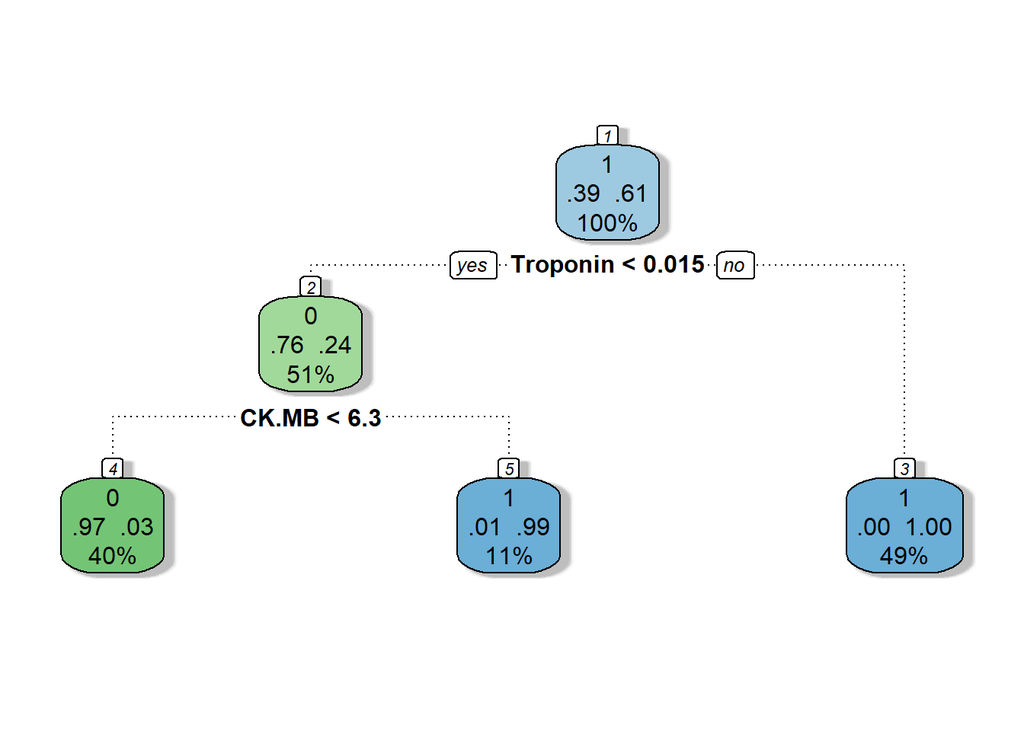

```r
model <- rpart(Result ~ ., method = "class", data = train)

fancyRpartPlot(model, caption = "")
```

### Testowanie dokładności modelu na zbiorze testowym

```r
model_test <- predict(model, test)
model_test <- as.data.frame(model_test)

model_test <- model_test %>%
  mutate(Result = ifelse(`0` >= .5, 0, 1))

table(test$Result, model_test$Result)
```

```
      0   1
  0 150   1
  1   4 239
```